# Isoform Pattern Interpretation: NMD Inhibition Effects

```r
# Additional analysis: Proportion vs Expression Level
cat("\n### Isoform Proportion vs Expression Level in DMSO\n\n")
```

```
##
## ### Isoform Proportion vs Expression Level in DMSO
```

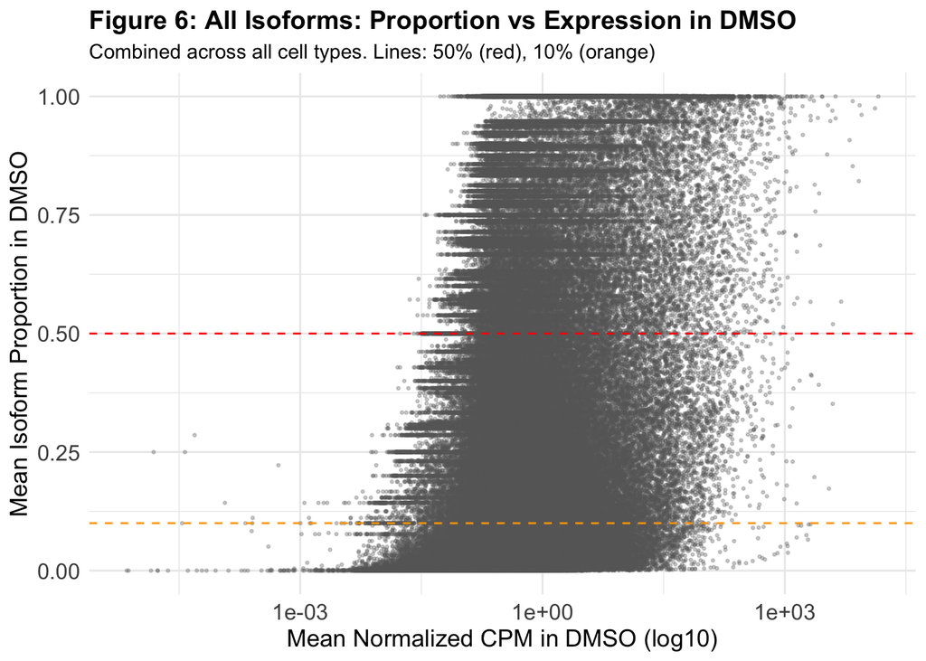

```r
# Plot 1: All isoforms (from filtered dataset)
all_dmso_proportions <- all_proportions %>%
  filter(treatment == "DMSO") %>%
  group_by(transcript_id, gene_id) %>%
  summarize(
    mean_cpm = mean(normalized_cpm),
    mean_proportion = mean(isoform_proportion),
    .groups = "drop"
  ) %>%
  filter(mean_cpm > 0)  # Only show expressed isoforms

ggplot(all_dmso_proportions, aes(x = mean_cpm, y = mean_proportion)) +
  geom_point(alpha = 0.3, size = 0.5, color = "gray40") +
  geom_hline(yintercept = 0.5, linetype = "dashed", color = "red") +
  geom_hline(yintercept = 0.1, linetype = "dashed", color = "orange") +
  scale_x_log10() +
  labs(title = "Figure 6: All Isoforms: Proportion vs Expression in DMSO",
       subtitle = "Combined across all cell types. Lines: 50% (red), 10% (orange)",
       x = "Mean Normalized CPM in DMSO (log10)",
       y = "Mean Isoform Proportion in DMSO") +
  theme_minimal() +
  theme(
    axis.text = element_text(size = 12),
    axis.title = element_text(size = 13),
    plot.title = element_text(size = 14, face = "bold"),
    plot.subtitle = element_text(size = 11)
  )
```

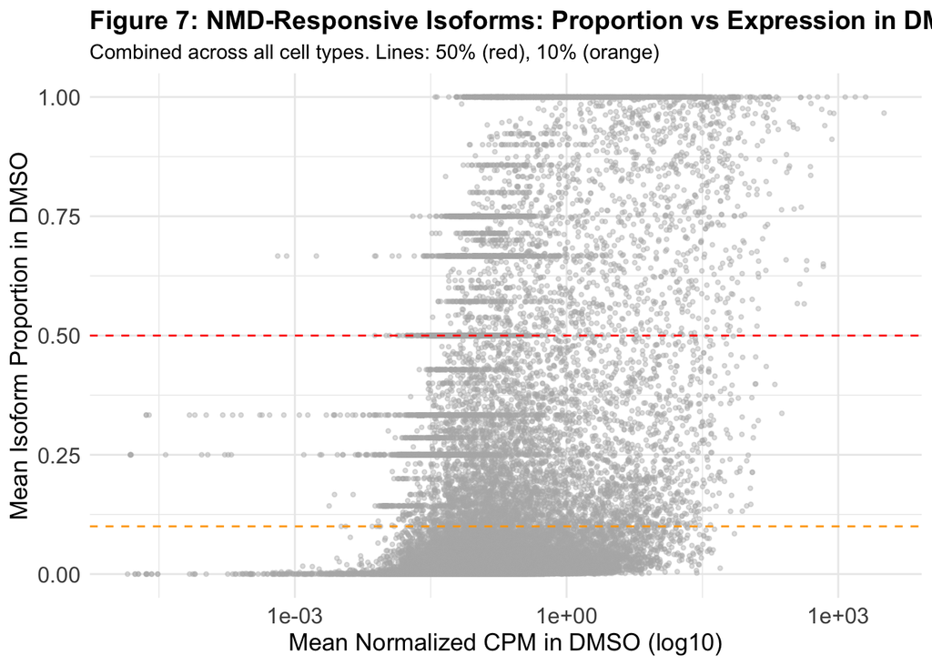

```r
# Plot 2: NMD-responsive isoforms in DMSO only
nmd_dmso_proportions <- baseline_proportions %>%
  group_by(transcript_id, gene_id) %>%
  summarize(
    mean_cpm = mean(normalized_cpm),
    mean_proportion = mean(isoform_proportion),
    .groups = "drop"
  ) %>%
  filter(mean_cpm > 0)  # Only show expressed isoforms

ggplot(nmd_dmso_proportions, aes(x = mean_cpm, y = mean_proportion)) +
  geom_point(alpha = 0.4, size = 0.8, color = "gray70") +
  geom_hline(yintercept = 0.5, linetype = "dashed", color = "red") +
  geom_hline(yintercept = 0.1, linetype = "dashed", color = "orange") +
  scale_x_log10() +
  labs(title = "Figure 7: NMD-Responsive Isoforms: Proportion vs Expression in DMSO",
       subtitle = "Combined across all cell types. Lines: 50% (red), 10% (orange)",
       x = "Mean Normalized CPM in DMSO (log10)",
       y = "Mean Isoform Proportion in DMSO") +
  theme_minimal() +
  theme(
    axis.text = element_text(size = 12),
    axis.title = element_text(size = 13),
    plot.title = element_text(size = 14, face = "bold"),
    plot.subtitle = element_text(size = 11)
  )
```

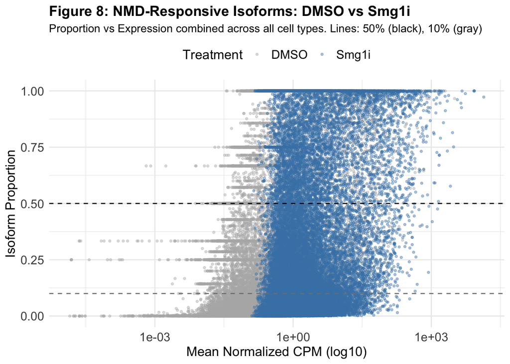

```r
# Plot 3: NMD-responsive isoforms - DMSO vs Smg1i comparison
nmd_dmso_data <- baseline_proportions %>%
  group_by(transcript_id, gene_id) %>%
  summarize(
    mean_cpm = mean(normalized_cpm),
    mean_proportion = mean(isoform_proportion),
    .groups = "drop"
  ) %>%
  filter(mean_cpm > 0) %>%
  mutate(treatment = "DMSO")

# Get Smg1i data for NMD-responsive isoforms
nmd_smg1i_data <- all_proportions %>%
  filter(treatment == "Smg1i") %>%
  inner_join(nmd_responsive, by = c("cell_type", "transcript_id")) %>%
  group_by(transcript_id, gene_id) %>%
  summarize(
    mean_cpm = mean(normalized_cpm),
    mean_proportion = mean(isoform_proportion),
    .groups = "drop"
  ) %>%
  filter(mean_cpm > 0) %>%
  mutate(treatment = "Smg1i")

# Combine for plotting
nmd_combined_data <- bind_rows(nmd_dmso_data, nmd_smg1i_data)

ggplot(nmd_combined_data, aes(x = mean_cpm, y = mean_proportion, color = treatment)) +
  geom_point(alpha = 0.4, size = 0.8) +
  geom_hline(yintercept = 0.5, linetype = "dashed", color = "black") +
  geom_hline(yintercept = 0.1, linetype = "dashed", color = "gray50") +
  scale_x_log10() +
  scale_color_manual(values = c("DMSO" = "gray70", "Smg1i" = "steelblue")) +
  labs(title = "Figure 8: NMD-Responsive Isoforms: DMSO vs Smg1i",
       subtitle = "Proportion vs Expression combined across all cell types. Lines: 50% (black), 10% (gray)",
       x = "Mean Normalized CPM (log10)",
       y = "Isoform Proportion",
       color = "Treatment") +
  theme_minimal() +
  theme(
    axis.text = element_text(size = 12),
    axis.title = element_text(size = 13),
    legend.text = element_text(size = 12),
    legend.title = element_text(size = 13),
    plot.title = element_text(size = 14, face = "bold"),
    plot.subtitle = element_text(size = 11),
    legend.position = "top"
  )
```

```r
cat("\n**Interpretation:**\n")
```

```
##
## **Interpretation:**
```

```r
cat("The first plot shows the overall relationship between proportion and expression for all isoforms.\n")
```

```
## The first plot shows the overall relationship between proportion and expression for all isoforms.
```

```r
cat("The second plot shows NMD-responsive isoforms in DMSO only - they cluster at low proportion and low expression.\n")
```

```
## The second plot shows NMD-responsive isoforms in DMSO only - they cluster at low proportion and low expression.
```

```r
cat("The third plot compares DMSO (gray) vs Smg1i (blue) for NMD-responsive isoforms.\n")
```

```
## The third plot compares DMSO (gray) vs Smg1i (blue) for NMD-responsive isoforms.
```

```r
cat("NMD-responsive isoforms shift rightward (increased expression) and often upward (increased proportion)\n")
```

```
## NMD-responsive isoforms shift rightward (increased expression) and often upward (increased proportion)
```

```r
cat("when NMD is inhibited, though many remain as minor isoforms even after rescue.\n\n")
```

```
## when NMD is inhibited, though many remain as minor isoforms even after rescue.
```

```r
# Get Smg1i proportions for comparison
# Note: Filter Smg1i by normalized_cpm > 0 (only need to consider expressed in Smg1i for comparison)
smg1i_proportions <- all_proportions %>%
  filter(treatment == "Smg1i", normalized_cpm > 0) %>%
  inner_join(nmd_responsive, by = c("cell_type", "transcript_id")) %>%
  select(cell_type, sample, gene_id, transcript_id, isoform_proportion) %>%
  rename(prop_smg1i = isoform_proportion)

# Figure 2: Overlapping density plot showing DMSO vs Smg1i distribution
cat("\n### Paired Distribution: DMSO vs Smg1i\n\n")
```

```
##
## ### Paired Distribution: DMSO vs Smg1i
```

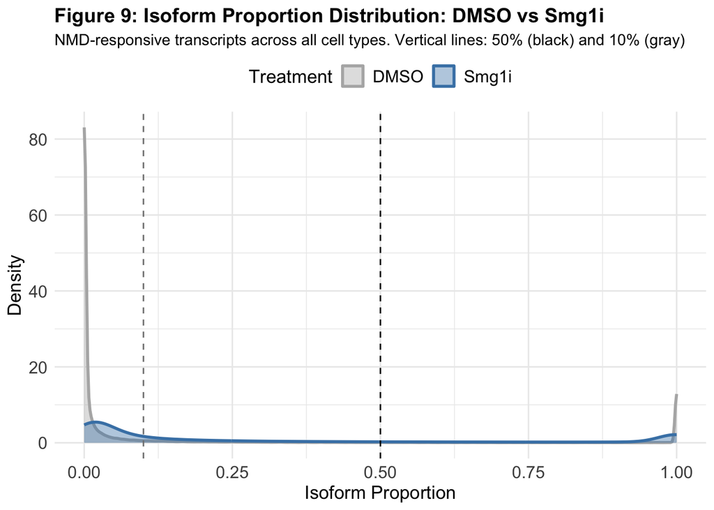

```r
# Combine DMSO and Smg1i proportions for density plot
dmso_for_density <- baseline_proportions %>%
  select(transcript_id, sample, isoform_proportion) %>%
  mutate(treatment = "DMSO")

smg1i_for_density <- smg1i_proportions %>%
  select(transcript_id, sample, prop_smg1i) %>%
  rename(isoform_proportion = prop_smg1i) %>%
  mutate(treatment = "Smg1i")

combined_proportions <- bind_rows(dmso_for_density, smg1i_for_density)

ggplot(combined_proportions, aes(x = isoform_proportion, fill = treatment, color = treatment)) +
  geom_density(alpha = 0.4, linewidth = 1) +
  geom_vline(xintercept = 0.5, linetype = "dashed", color = "black", linewidth = 0.5) +
  geom_vline(xintercept = 0.1, linetype = "dashed", color = "gray50", linewidth = 0.5) +
  scale_fill_manual(values = c("DMSO" = "gray70", "Smg1i" = "steelblue")) +
  scale_color_manual(values = c("DMSO" = "gray70", "Smg1i" = "steelblue")) +
  labs(title = "Figure 9: Isoform Proportion Distribution: DMSO vs Smg1i",
       subtitle = "NMD-responsive transcripts across all cell types. Vertical lines: 50% (black) and 10% (gray)",
       x = "Isoform Proportion",
       y = "Density",
       fill = "Treatment",
       color = "Treatment") +
  theme_minimal() +
  theme(
    axis.text = element_text(size = 12),
    axis.title = element_text(size = 13),
    legend.text = element_text(size = 12),
    legend.title = element_text(size = 13),
    plot.title = element_text(size = 14, face = "bold"),
    plot.subtitle = element_text(size = 11),
    legend.position = "top"
  )
```

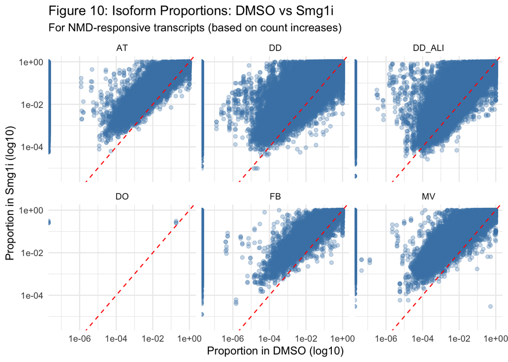

```r
# Compare before/after
before_after <- baseline_proportions %>%
  select(cell_type, sample, transcript_id, prop_dmso = isoform_proportion) %>%
  inner_join(
    smg1i_proportions %>%
      select(cell_type, sample_orig = sample, transcript_id, prop_smg1i),
    by = c("cell_type", "transcript_id"),
    relationship = "many-to-many"
  ) %>%
  mutate(
    fold_change_prop = prop_smg1i / prop_dmso,
    log2_fc_prop = log2(fold_change_prop)
  )

# Plot before vs after - PROPORTIONS
ggplot(before_after, aes(x = prop_dmso, y = prop_smg1i)) +
  geom_point(alpha = 0.3, color = "steelblue") +
  geom_abline(slope = 1, intercept = 0, linetype = "dashed", color = "red") +
  facet_wrap(~cell_type) +
  scale_x_log10() +
  scale_y_log10() +
  labs(title = "Figure 10: Isoform Proportions: DMSO vs Smg1i",
       subtitle = "For NMD-responsive transcripts (based on count increases)",
       x = "Proportion in DMSO (log10)",
       y = "Proportion in Smg1i (log10)") +
  theme_minimal()
```

```r
cat("\n**Important Note on Proportions vs Counts:**\n\n")
```

```
##
## **Important Note on Proportions vs Counts:**
```

```r
cat("These transcripts are 'NMD-responsive' based on NORMALIZED COUNT increases in the DGE analysis.\n")
```

```
## These transcripts are 'NMD-responsive' based on NORMALIZED COUNT increases in the DGE analysis.
```

```r
cat("However, their ISOFORM PROPORTION (fraction of gene expression) may not increase if:\n")
```

```
## However, their ISOFORM PROPORTION (fraction of gene expression) may not increase if:
```

```r
cat("- The whole gene is upregulated proportionally (all isoforms increase together)\n")
```

```
## - The whole gene is upregulated proportionally (all isoforms increase together)
```

```r
cat("- Other isoforms of the same gene increase even more\n\n")
```

```
## - Other isoforms of the same gene increase even more
```

```r
cat("Points below the diagonal indicate transcripts where counts increased but proportion decreased,\n")
```

```
## Points below the diagonal indicate transcripts where counts increased but proportion decreased,
```

```r
cat("suggesting other isoforms of that gene increased more dramatically.\n\n")
```

```
## suggesting other isoforms of that gene increased more dramatically.
```

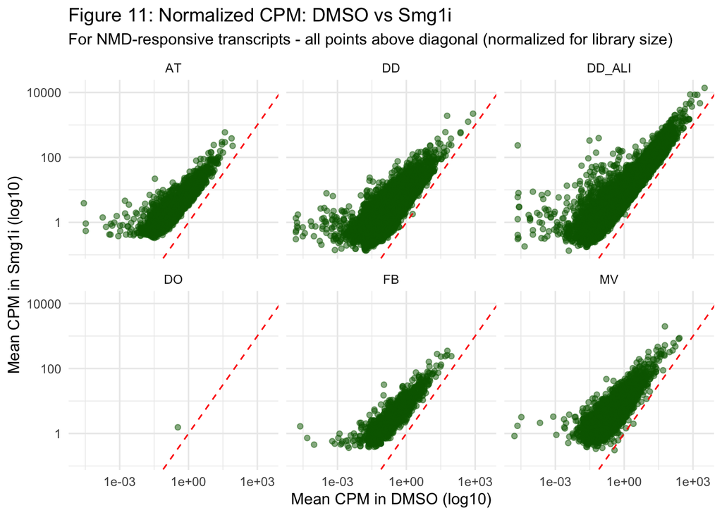

```r
# Convert CPM matrix to long format with sample metadata
# Use txid from genes slot to match with DGE results
cpm_df <- as.data.frame(cpm_normalized)
cpm_df$transcript_id <- dge_isoform$genes$txid

cpm_long <- cpm_df %>%
  pivot_longer(cols = -transcript_id, names_to = "bamid", values_to = "cpm") %>%
  left_join(dge_isoform$samples %>% select(bamid, sample, treatment, ct),
            by = "bamid") %>%
  rename(cell_type = ct)

# Calculate mean normalized CPM per treatment per cell type per transcript
mean_cpm <- cpm_long %>%
  inner_join(nmd_responsive, by = c("cell_type", "transcript_id")) %>%
  group_by(cell_type, treatment, transcript_id) %>%
  summarize(
    mean_cpm = mean(cpm),
    .groups = "drop"
  ) %>%
  pivot_wider(
    names_from = treatment,
    values_from = mean_cpm,
    names_prefix = "mean_cpm_"
  ) %>%
  filter(mean_cpm_DMSO > 0, mean_cpm_Smg1i > 0) %>%  # Only transcripts detected in both
  mutate(
    cpm_fc = mean_cpm_Smg1i / mean_cpm_DMSO,
    log2_cpm_fc = log2(cpm_fc)
  )

# Plot using NORMALIZED CPM (accounts for library size and sequencing depth)
ggplot(mean_cpm, aes(x = mean_cpm_DMSO, y = mean_cpm_Smg1i)) +
  geom_point(alpha = 0.5, color = "darkgreen") +
  geom_abline(slope = 1, intercept = 0, linetype = "dashed", color = "red") +
  facet_wrap(~cell_type) +
  scale_x_log10() +
  scale_y_log10() +
  labs(title = "Figure 11: Normalized CPM: DMSO vs Smg1i",
       subtitle = "For NMD-responsive transcripts - all points above diagonal (normalized for library size)",
       x = "Mean CPM in DMSO (log10)",
       y = "Mean CPM in Smg1i (log10)") +
  theme_minimal()
```

```r
cat("\nIn the count-based plot above, ALL points are now above the diagonal,\n")
```

```
##
## In the count-based plot above, ALL points are now above the diagonal,
```

```r
cat("confirming these transcripts have increased expression in Smg1i.\n")
```

```
## confirming these transcripts have increased expression in Smg1i.
```

```r
cat("Using NORMALIZED CPM accounts for differences in sequencing depth across samples,\n")
```

```
## Using NORMALIZED CPM accounts for differences in sequencing depth across samples,
```

```r
cat("making the plot consistent with DGE results (which also use normalized counts).\n\n")
```

```
## making the plot consistent with DGE results (which also use normalized counts).
```

```r
# Save results
write_tsv(baseline_proportions, OUTPUT_Q3)
cat("\nSaved:", OUTPUT_Q3, "\n")
```

```
##
## Saved: ../tmp/isoform_interpretation_q3_upregulated_baseline_2026.1.3.tsv
```

# 7 Q4: Cell-Type Specificity

**Question:** Are isoform patterns consistent or cell-type-specific?

```r
# Compare Q1-Q3 metrics across cell types

# Q1: Isoform gain consistency
q1_celltype <- q1_summary %>%
  select(cell_type, mean_delta, pct_more_tx_smg1i) %>%
  mutate(metric = "Isoform Gain")

# Q2: Dominant isoform consistency
q2_celltype <- q2_comparison %>%
  select(cell_type, delta_pct) %>%
  rename(value = delta_pct) %>%
  mutate(metric = "Dominant Isoform Change (%)")

# Q3: Baseline proportion consistency
q3_celltype <- q3_summary %>%
  select(cell_type, median_baseline_prop, pct_very_minor) %>%
  mutate(metric = "Upregulated Baseline")

cat("## Cell-Type Comparison\n\n")
```

```
## ## Cell-Type Comparison
```

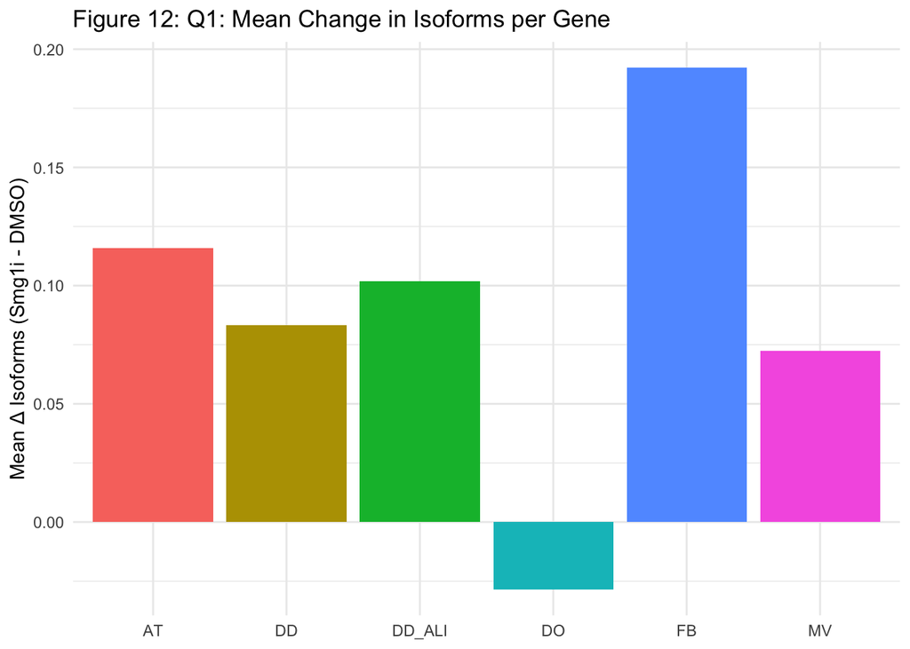

```r
# Plot comparison
p1 <- ggplot(q1_summary, aes(x = cell_type, y = mean_delta, fill = cell_type)) +
  geom_col() +
  labs(title = "Figure 12: Q1: Mean Change in Isoforms per Gene",
       y = "Mean Δ Isoforms (Smg1i - DMSO)",
       x = NULL) +
  theme_minimal() +
  theme(legend.position = "none")

p2 <- ggplot(q2_comparison, aes(x = cell_type, y = delta_pct, fill = cell_type)) +
  geom_col() +
  labs(title = "Figure 13: Q2: Change in Dominant Isoform Prevalence",
       y = "Δ % Genes with Dominant Isoform",
       x = NULL) +
  theme_minimal() +
  theme(legend.position = "none")

p3 <- ggplot(q3_summary, aes(x = cell_type, y = median_baseline_prop, fill = cell_type)) +
  geom_col() +
  labs(title = "Figure 14: Q3: Median Baseline Proportion",
       subtitle = "For NMD-responsive transcripts",
       y = "Median Proportion in DMSO",
       x = NULL) +
  theme_minimal() +
  theme(legend.position = "none")

# Display plots
print(p1)
```

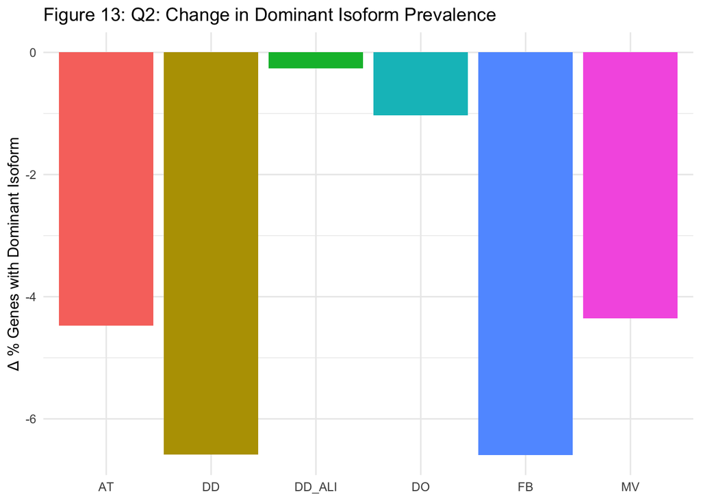

```r
print(p2)
```

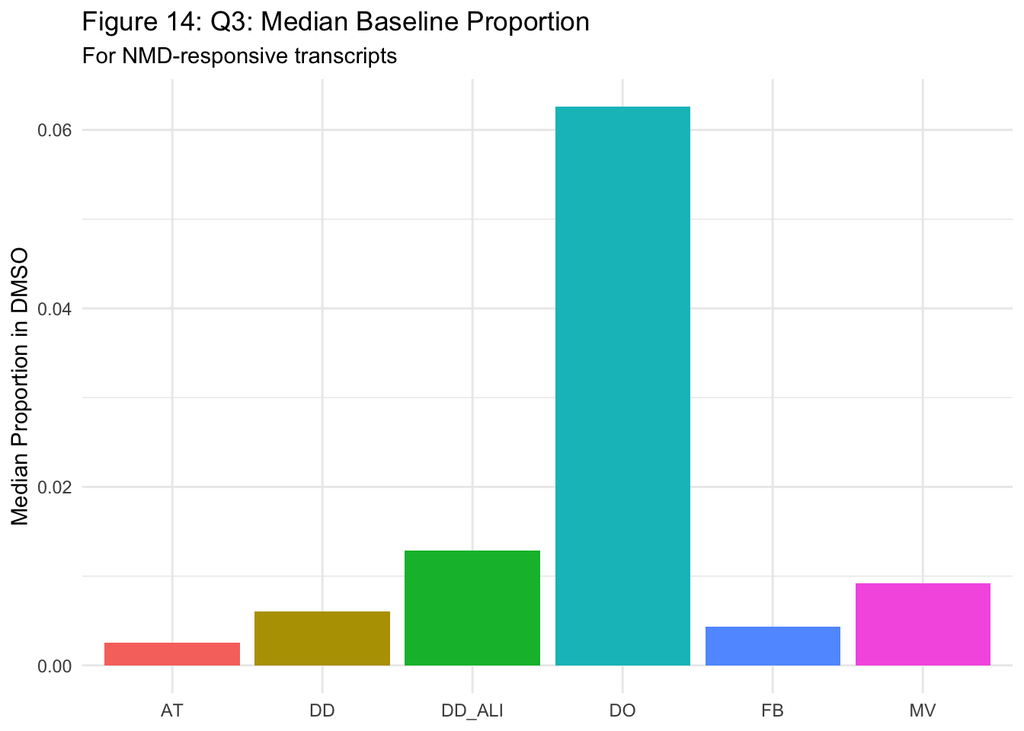

```r
print(p3)
```

```r
# Statistical summary
q4_summary <- data.frame(
  metric = c("Mean Δ Isoforms", "Δ % Dominant", "Median Baseline Prop"),
  across_celltypes_mean = c(
    mean(q1_summary$mean_delta),
    mean(q2_comparison$delta_pct),
    mean(q3_summary$median_baseline_prop)
  ),
  across_celltypes_sd = c(
    sd(q1_summary$mean_delta),
    sd(q2_comparison$delta_pct),
    sd(q3_summary$median_baseline_prop)
  ),
  range_min = c(
    min(q1_summary$mean_delta),
    min(q2_comparison$delta_pct),
    min(q3_summary$median_baseline_prop)
  ),
  range_max = c(
    max(q1_summary$mean_delta),
    max(q2_comparison$delta_pct),
    max(q3_summary$median_baseline_prop)
  )
)

cat("\n## Cross-Cell-Type Variability\n\n")
```

```
##
## ## Cross-Cell-Type Variability
```

```r
datatable(q4_summary,
          options = list(pageLength = 5),
          caption = "Consistency of patterns across cell types") %>%
  formatRound(columns = 2:5, digits = 3)
```

|  | metric | across_celltypes_mean | across_celltypes_sd | range_min | range_max |
| --- | --- | --- | --- | --- | --- |
| 1 | Mean Δ Isoforms | 0.0895183299011858 | 0.07160853877178226 | -0.02851477828373633 | 0.1920919203408455 |
| 2 | Δ % Dominant | -3.882279076004602 | 2.70171010625206 | -6.592494644854398 | -0.2606577306859634 |
| 3 | Median Baseline Prop | 0.01625347248704676 | 0.0229903202671485 | 0.00253836390908042 | 0.06258463919520216 |

```r
# Save results
write_tsv(q4_summary, OUTPUT_Q4)
cat("\nSaved:", OUTPUT_Q4, "\n")
```

```
##
## Saved: ../tmp/isoform_interpretation_q4_celltype_comparison_2026.1.3.tsv
```

# 8 Q5: Transcriptional Output Devoted to NMD

**Question:** What proportion of transcriptional output is devoted to producing NMD-targeted transcripts?

**Concept:** In the Smg1i condition (NMD inhibited), we observe the true transcriptional output of genes without degradation. This allows us to estimate what fraction of a gene’s transcriptional resources are devoted to producing transcripts that are normally targeted for NMD degradation.

```r
cat("## Transcriptional Output Analysis\n\n")
```

```
## ## Transcriptional Output Analysis
```

```r
# Use Smg1i data to estimate true transcriptional output (NMD is off)
smg1i_expression <- all_proportions %>%
  filter(treatment == "Smg1i") %>%
  group_by(cell_type, gene_id, transcript_id) %>%
  summarize(
    mean_cpm = mean(normalized_cpm),
    .groups = "drop"
  )

# Identify which transcripts are NMD-responsive
nmd_responsive_set <- nmd_responsive %>%
  select(cell_type, transcript_id) %>%
  distinct() %>%
  mutate(is_nmd_responsive = TRUE)

# Join to mark NMD-responsive transcripts
smg1i_expression <- smg1i_expression %>%
  left_join(nmd_responsive_set, by = c("cell_type", "transcript_id")) %>%
  mutate(is_nmd_responsive = replace_na(is_nmd_responsive, FALSE))

# Gene-level analysis: For genes with NMD-responsive isoforms,
# what % of transcriptional output goes to NMD?
gene_nmd_output <- smg1i_expression %>%
  group_by(cell_type, gene_id) %>%
  summarize(
    total_output = sum(mean_cpm),
    nmd_output = sum(mean_cpm[is_nmd_responsive]),
    n_isoforms = n(),
    n_nmd_isoforms = sum(is_nmd_responsive),
    has_nmd_isoform = any(is_nmd_responsive),
    .groups = "drop"
  ) %>%
  filter(has_nmd_isoform, total_output > 0) %>%
  mutate(
    pct_to_nmd = 100 * nmd_output / total_output
  )

cat("### Gene-Level Analysis\n\n")
```

```
## ### Gene-Level Analysis
```

```r
cat("For genes harboring NMD-responsive isoforms:\n\n")
```

```
## For genes harboring NMD-responsive isoforms:
```

```r
# Summary by cell type
gene_summary <- gene_nmd_output %>%
  group_by(cell_type) %>%
  summarize(
    n_genes = n(),
    mean_pct_to_nmd = mean(pct_to_nmd),
    median_pct_to_nmd = median(pct_to_nmd),
    q25_pct = quantile(pct_to_nmd, 0.25),
    q75_pct = quantile(pct_to_nmd, 0.75),
    .groups = "drop"
  )

print(gene_summary)
```

```
## # A tibble: 6 × 6
##   cell_type n_genes mean_pct_to_nmd median_pct_to_nmd q25_pct q75_pct
##   <chr>       <int>           <dbl>             <dbl>   <dbl>   <dbl>
## 1 AT           4316            40.8              24.3    5.54    84.1
## 2 DD          13532            53.3              48.9   14.1    100
## 3 DD_ALI       8151            60.9              72.7   19.5    100
## 4 DO              1            27.2              27.2   27.2     27.2
## 5 FB           1820            37.7              18.6    3.85    80.5
## 6 MV           3344            46.1              33.9    8.04    91.9
```

```r
cat("\n")
```

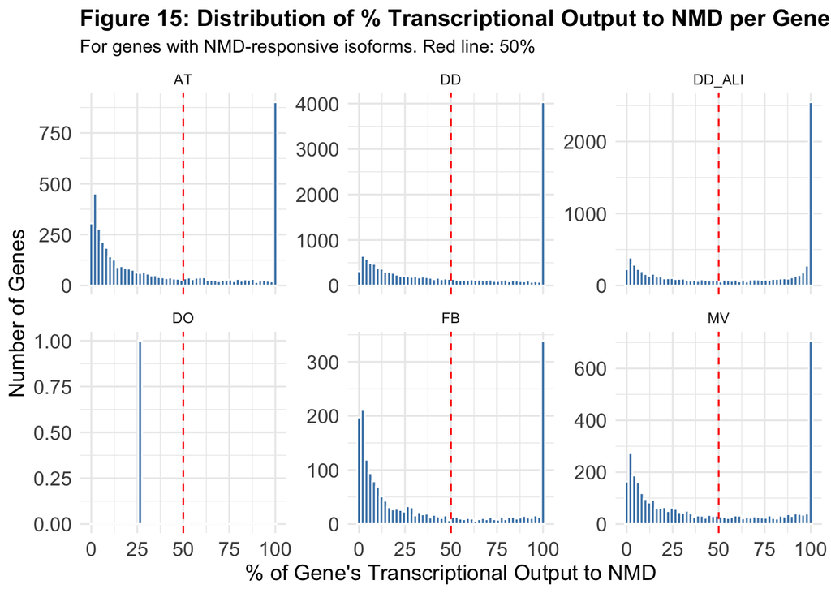

```r
# Distribution plot
ggplot(gene_nmd_output, aes(x = pct_to_nmd)) +
  geom_histogram(bins = 50, fill = "steelblue", color = "white") +
  facet_wrap(~cell_type, scales = "free_y") +
  geom_vline(xintercept = 50, linetype = "dashed", color = "red") +
  labs(title = "Figure 15: Distribution of % Transcriptional Output to NMD per Gene",
       subtitle = "For genes with NMD-responsive isoforms. Red line: 50%",
       x = "% of Gene's Transcriptional Output to NMD",
       y = "Number of Genes") +
  theme_minimal() +
  theme(
    axis.text = element_text(size = 12),
    axis.title = element_text(size = 13),
    plot.title = element_text(size = 14, face = "bold"),
    plot.subtitle = element_text(size = 11)
  )
```

```r
# Cell-type level analysis: Overall % of transcriptional output to NMD
cat("\n### Cell-Type Level Analysis\n\n")
```

```
##
## ### Cell-Type Level Analysis
```

```r
cat("Overall transcriptional output devoted to NMD-targeted transcripts:\n\n")
```

```
## Overall transcriptional output devoted to NMD-targeted transcripts:
```

```r
cat("**Calculation:** For each sample, calculate (NMD-responsive CPM sum) / (total CPM sum for genes with NMD isoforms),\n")
```

```
## **Calculation:** For each sample, calculate (NMD-responsive CPM sum) / (total CPM sum for genes with NMD isoforms),
```

```r
cat("then average percentages across samples within each cell type.\n\n")
```

```
## then average percentages across samples within each cell type.
```

```r
# Get per-sample CPM values for genes with NMD-responsive isoforms
celltype_nmd_persample <- all_proportions %>%
  filter(treatment == "Smg1i") %>%
  # Only include genes with NMD-responsive isoforms
  inner_join(
    gene_nmd_output %>% select(cell_type, gene_id),
    by = c("cell_type", "gene_id")
  ) %>%
  # Mark NMD-responsive transcripts
  left_join(nmd_responsive_set, by = c("cell_type", "transcript_id")) %>%
  mutate(is_nmd_responsive = replace_na(is_nmd_responsive, FALSE)) %>%
  # Calculate percentage per sample
  group_by(cell_type, sample) %>%
  summarize(
    total_cpm = sum(normalized_cpm),
    nmd_cpm = sum(normalized_cpm[is_nmd_responsive]),
    pct_to_nmd = 100 * nmd_cpm / total_cpm,
    .groups = "drop"
  )

# Average across samples within cell type
celltype_nmd_output <- celltype_nmd_persample %>%
  group_by(cell_type) %>%
  summarize(
    mean_pct_to_nmd = mean(pct_to_nmd),
    sd_pct_to_nmd = sd(pct_to_nmd),
    n_samples = n(),
    .groups = "drop"
  ) %>%
  rename(pct_to_nmd = mean_pct_to_nmd)

print(celltype_nmd_output)
```

```
## # A tibble: 6 × 4
##   cell_type pct_to_nmd sd_pct_to_nmd n_samples
##   <chr>          <dbl>         <dbl>     <int>
## 1 AT              8.19         0.626         3
## 2 DD             15.5          1.35          4
## 3 DD_ALI         54.1          6.72          3
## 4 DO             27.2          3.00          3
## 5 FB              5.10         0.972         3
## 6 MV             11.6          1.58          3
```

```r
cat("\n")
```

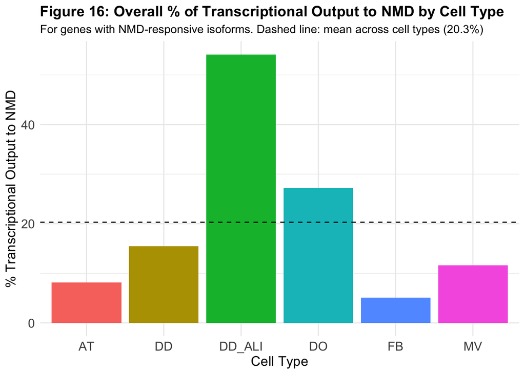

```r
# Visualization
ggplot(celltype_nmd_output, aes(x = cell_type, y = pct_to_nmd, fill = cell_type)) +
  geom_col() +
  geom_hline(yintercept = mean(celltype_nmd_output$pct_to_nmd),
             linetype = "dashed", color = "black") +
  labs(title = "Figure 16: Overall % of Transcriptional Output to NMD by Cell Type",
       subtitle = paste0("For genes with NMD-responsive isoforms. Dashed line: mean across cell types (",
                        round(mean(celltype_nmd_output$pct_to_nmd), 1), "%)"),
       x = "Cell Type",
       y = "% Transcriptional Output to NMD",
       fill = "Cell Type") +
  theme_minimal() +
  theme(
    axis.text = element_text(size = 12),
    axis.title = element_text(size = 13),
    plot.title = element_text(size = 14, face = "bold"),
    plot.subtitle = element_text(size = 11),
    legend.position = "none"
  )
```

```r
cat("\n### Alternative Calculation: NMD Output as % of Total Cell-Type Transcriptional Output\n\n")
```

```
##
## ### Alternative Calculation: NMD Output as % of Total Cell-Type Transcriptional Output
```

```r
cat("**Transcriptional output definition:** For each sample, sum CPM for ALL transcripts in the cell type,\n")
```

```
## **Transcriptional output definition:** For each sample, sum CPM for ALL transcripts in the cell type,
```

```r
cat("using the complete unfiltered dataset (not limited to abundance-filtered transcripts or genes with NMD-responsive isoforms).\n\n")
```

```
## using the complete unfiltered dataset (not limited to abundance-filtered transcripts or genes with NMD-responsive isoforms).
```

```r
cat("**Calculation:** For each sample, calculate (NMD-responsive CPM sum) / (ALL transcripts CPM sum),\n")
```

```
## **Calculation:** For each sample, calculate (NMD-responsive CPM sum) / (ALL transcripts CPM sum),
```

```r
cat("then average percentages across samples within each cell type.\n\n")
```

```
## then average percentages across samples within each cell type.
```

```r
cat("This provides a different perspective on the 'cost' of NMD by showing what percentage of the\n")
```

```
## This provides a different perspective on the 'cost' of NMD by showing what percentage of the
```

```r
cat("entire transcriptional output of the cell type is devoted to NMD-targeted transcripts.\n\n")
```

```
## entire transcriptional output of the cell type is devoted to NMD-targeted transcripts.
```

```r
# Calculate using ALL transcripts (unfiltered) from the full CPM data, per sample
cpm_long_full <- as.data.frame(cpm_normalized) %>%
  mutate(transcript_id = dge_isoform$genes$txid) %>%
  pivot_longer(cols = -transcript_id, names_to = "bamid", values_to = "cpm") %>%
  left_join(dge_isoform$samples %>% select(bamid, sample, treatment, ct),
            by = "bamid") %>%
  rename(cell_type = ct)

# Calculate per-sample percentages for Smg1i
celltype_nmd_total_persample <- cpm_long_full %>%
  filter(treatment == "Smg1i") %>%
  # Mark NMD-responsive transcripts
  left_join(nmd_responsive_set, by = c("cell_type", "transcript_id")) %>%
  mutate(is_nmd_responsive = replace_na(is_nmd_responsive, FALSE)) %>%
  # Calculate percentage per sample
  group_by(cell_type, sample) %>%
  summarize(
    total_cpm = sum(cpm),
    nmd_cpm = sum(cpm[is_nmd_responsive]),
    pct_to_nmd = 100 * nmd_cpm / total_cpm,
    .groups = "drop"
  )

cat("Per-sample check (first few samples):\n")
```

```
## Per-sample check (first few samples):
```

```r
print(head(celltype_nmd_total_persample, 10))
```

```
## # A tibble: 10 × 5
##    cell_type sample        total_cpm nmd_cpm pct_to_nmd
##    <chr>     <chr>             <dbl>   <dbl>      <dbl>
##  1 AT        AT2001V_Smg1i   959074.  22768.       2.37
##  2 AT        AT2027U_Smg1i   773631.  18346.       2.37
##  3 AT        AT2029T_Smg1i   918746.  25634.       2.79
##  4 DD        DD010R_Smg1i    953969.  75019.       7.86
##  5 DD        DD017Q_Smg1i    705477.  70561.      10.0
##  6 DD        DD047N_Smg1i    720875.  66197.       9.18
##  7 DD        DD066Q_Smg1i    872792.  74417.       8.53
##  8 DD_ALI    DD001V_Smg1i   1093419. 387957.      35.5
##  9 DD_ALI    DD027U_Smg1i   1276982. 397766.      31.1
## 10 DD_ALI    DD029T_Smg1i   1187651. 449225.      37.8
```

```r
cat("\n")
```

```r
cat("Note: total_cpm should be approximately 1,000,000 per sample (CPM normalization)\n\n")
```

```
## Note: total_cpm should be approximately 1,000,000 per sample (CPM normalization)
```

```r
# Average across samples within cell type
celltype_nmd_output_total <- celltype_nmd_total_persample %>%
  group_by(cell_type) %>%
  summarize(
    mean_pct_to_nmd = mean(pct_to_nmd),
    sd_pct_to_nmd = sd(pct_to_nmd),
    n_samples = n(),
    mean_total_cpm = mean(total_cpm),
    .groups = "drop"
  ) %>%
  rename(pct_to_nmd = mean_pct_to_nmd)

cat("Cell-type transcriptional output to NMD (as % of total cell-type output):\n\n")
```

```
## Cell-type transcriptional output to NMD (as % of total cell-type output):
```

```r
print(celltype_nmd_output_total)
```

```
## # A tibble: 6 × 5
##   cell_type pct_to_nmd sd_pct_to_nmd n_samples mean_total_cpm
##   <chr>          <dbl>         <dbl>     <int>          <dbl>
## 1 AT          2.51         0.241             3        883817.
## 2 DD          8.89         0.914             4        813278.
## 3 DD_ALI     34.8          3.39              3       1186017.
## 4 DO          0.000212     0.0000401         3        733867.
## 5 FB          0.962        0.301             3       1198430.
## 6 MV          3.51         0.334             3       1159926.
```

```r
cat("\n")
```

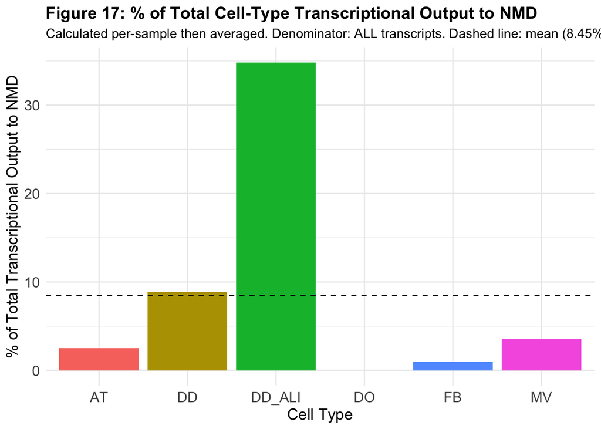

```r
# Visualization
ggplot(celltype_nmd_output_total, aes(x = cell_type, y = pct_to_nmd, fill = cell_type)) +
  geom_col() +
  geom_hline(yintercept = mean(celltype_nmd_output_total$pct_to_nmd),
             linetype = "dashed", color = "black") +
  labs(title = "Figure 17: % of Total Cell-Type Transcriptional Output to NMD",
       subtitle = paste0("Calculated per-sample then averaged. Denominator: ALL transcripts. Dashed line: mean (",
                        round(mean(celltype_nmd_output_total$pct_to_nmd), 2), "%)"),
       x = "Cell Type",
       y = "% of Total Transcriptional Output to NMD",
       fill = "Cell Type") +
  theme_minimal() +
  theme(
    axis.text = element_text(size = 12),
    axis.title = element_text(size = 13),
    plot.title = element_text(size = 14, face = "bold"),
    plot.subtitle = element_text(size = 11),
    legend.position = "none"
  )
```

```r
cat("\n**Comparison of Figure 16 vs Figure 17:**\n")
```

```
##
## **Comparison of Figure 16 vs Figure 17:**
```

```r
cat("- **Figure 16**: Denominator is CPM sum of transcripts from genes with ≥1 NMD-responsive isoform\n")
```

```
## - **Figure 16**: Denominator is CPM sum of transcripts from genes with ≥1 NMD-responsive isoform
```

```r
cat("  - Shows: Within genes affected by NMD, what % of their output goes to NMD targets?\n")
```

```
##   - Shows: Within genes affected by NMD, what % of their output goes to NMD targets?
```

```r
cat("  - This will always be higher than Figure 17 because the denominator is smaller\n")
```

```
##   - This will always be higher than Figure 17 because the denominator is smaller
```

```r
cat("- **Figure 17**: Denominator is CPM sum of ALL transcripts in the cell type (should ≈1M per sample)\n")
```

```
## - **Figure 17**: Denominator is CPM sum of ALL transcripts in the cell type (should ≈1M per sample)
```

```r
cat("  - Shows: What % of the cell's entire transcriptional capacity is devoted to NMD targets?\n")
```

```
##   - Shows: What % of the cell's entire transcriptional capacity is devoted to NMD targets?
```

```r
cat("  - Provides a genome-wide perspective on the cost of NMD\n\n")
```

```
##   - Provides a genome-wide perspective on the cost of NMD
```

```r
cat("Both calculations now correctly compute percentages per-sample before averaging across samples.\n\n")
```

```
## Both calculations now correctly compute percentages per-sample before averaging across samples.
```

```r
cat("\n**Interpretation:**\n")
```

```
##
## **Interpretation:**
```

```r
cat("This analysis quantifies the 'cost' of NMD - the fraction of transcriptional resources\n")
```

```
## This analysis quantifies the 'cost' of NMD - the fraction of transcriptional resources
```

```r
cat("devoted to producing transcripts that are normally degraded by NMD.\n")
```

```
## devoted to producing transcripts that are normally degraded by NMD.
```

```r
cat("The Smg1i condition reveals this hidden transcriptional output.\n\n")
```

```
## The Smg1i condition reveals this hidden transcriptional output.
```

```r
# Save results
write_tsv(gene_nmd_output, OUTPUT_Q5_GENE)
write_tsv(celltype_nmd_output, OUTPUT_Q5_CELLTYPE)
write_tsv(celltype_nmd_output_total, OUTPUT_Q5_TOTAL)
cat("Saved:", OUTPUT_Q5_GENE, "\n")
```

```
## Saved: ../tmp/isoform_interpretation_q5_gene_nmd_output_2026.1.3.tsv
```

```r
cat("Saved:", OUTPUT_Q5_CELLTYPE, "\n")
```

```
## Saved: ../tmp/isoform_interpretation_q5_celltype_nmd_output_2026.1.3.tsv
```

```r
cat("Saved:", OUTPUT_Q5_TOTAL, "\n")
```

```
## Saved: ../tmp/isoform_interpretation_q5_celltype_nmd_output_total_2026.1.3.tsv
```

# 9 Q6: Gene Set Enrichment Analysis

**Question:** Which biological pathways and gene sets are enriched among genes that devote a large proportion of their transcriptional output to NMD-targeted isoforms?

**Approach:** Use Gene Set Enrichment Analysis (GSEA) with genes ranked by `pct_to_nmd` (percentage of transcriptional output going to NMD). This will identify pathways where genes collectively allocate substantial resources to producing NMD-targeted transcripts.

```r
cat("## GSEA: Pathways Enriched for High NMD Transcriptional Output\n\n")
```

```
## ## GSEA: Pathways Enriched for High NMD Transcriptional Output
```

```r
# Set CRAN mirror
options(repos = c(CRAN = "https://cloud.r-project.org"))

# Load GSEA libraries
if (!require("fgsea", quietly = TRUE)) {
  if (!require("BiocManager", quietly = TRUE)) {
    install.packages("BiocManager")
  }
  BiocManager::install("fgsea")
  library(fgsea)
}

if (!require("msigdbr", quietly = TRUE)) {
  install.packages("msigdbr")
  library(msigdbr)
}

library(fgsea)
library(msigdbr)

# GSEA parameters
GSEA_MIN_SIZE <- 15
GSEA_MAX_SIZE <- 500
GSEA_NPERM <- 10000
SIGNIFICANCE_THRESHOLD <- 0.05

cat("GSEA Parameters:\n")
```

```
## GSEA Parameters:
```

```r
cat("- Pathway size: ", GSEA_MIN_SIZE, "-", GSEA_MAX_SIZE, " genes\n")
```

```
## - Pathway size:  15 - 500  genes
```

```r
cat("- Permutations: ", GSEA_NPERM, "\n")
```

```
## - Permutations:  10000
```

```r
cat("- Significance threshold: FDR < ", SIGNIFICANCE_THRESHOLD, "\n\n")
```

```
## - Significance threshold: FDR <  0.05
```

```r
cat("## Loading MSigDB Gene Sets\n\n")
```

```
## ## Loading MSigDB Gene Sets
```

```r
# Load MSigDB gene sets for human
cat("Loading Hallmark gene sets...\n")
```

```
## Loading Hallmark gene sets...
```

```r
msigdb_h <- msigdbr(species = "Homo sapiens", category = "H")

cat("Loading GO Biological Process gene sets...\n")
```

```
## Loading GO Biological Process gene sets...
```

```r
msigdb_bp <- msigdbr(species = "Homo sapiens", category = "C5", subcategory = "GO:BP")

cat("Loading KEGG gene sets...\n")
```

```
## Loading KEGG gene sets...
```

```r
msigdb_kegg <- msigdbr(species = "Homo sapiens", category = "C2", subcategory = "CP:KEGG_LEGACY")

cat("Loading Reactome gene sets...\n")
```

```
## Loading Reactome gene sets...
```

```r
msigdb_reactome <- msigdbr(species = "Homo sapiens", category = "C2", subcategory = "CP:REACTOME")

# Combine all gene sets
all_genesets <- bind_rows(
  msigdb_h %>% mutate(collection = "Hallmark"),
  msigdb_bp %>% mutate(collection = "GO_BP"),
  msigdb_kegg %>% mutate(collection = "KEGG"),
  msigdb_reactome %>% mutate(collection = "Reactome")
)

cat("\nGene set summary:\n")
```

```
##
## Gene set summary:
```

```r
geneset_summary <- all_genesets %>%
  group_by(collection) %>%
  summarize(
    n_genesets = n_distinct(gs_name),
    n_genes = n_distinct(gene_symbol),
    .groups = "drop"
  )
print(geneset_summary)
```

```
## # A tibble: 4 × 3
##   collection n_genesets n_genes
##   <chr>           <int>   <int>
## 1 GO_BP            7583   18000
## 2 Hallmark           50    4384
## 3 KEGG              186    5245
## 4 Reactome         1787   11369
```

```r
# Convert to fgsea format (named list)
pathways <- all_genesets %>%
  split(x = .$gene_symbol, f = .$gs_name)

# Filter by size
pathways_filtered <- pathways[
  sapply(pathways, length) >= GSEA_MIN_SIZE &
  sapply(pathways, length) <= GSEA_MAX_SIZE
]

cat("\nTotal pathways before filtering:", length(pathways), "\n")
```

```
##
## Total pathways before filtering: 9606
```

```r
cat("Pathways after size filtering (", GSEA_MIN_SIZE, "-", GSEA_MAX_SIZE, " genes):", length(pathways_filtered), "\n\n")
```

```
## Pathways after size filtering ( 15 - 500  genes): 5632
```

```r
cat("## Preparing Gene-Level Ranked Lists\n\n")
```

```
## ## Preparing Gene-Level Ranked Lists
```

```r
cat("**Ranking strategy:**\n")
```

```
## **Ranking strategy:**
```

```r
cat("- Rank ALL genes by pct_to_nmd (percentage of transcriptional output going to NMD)\n")
```

```
## - Rank ALL genes by pct_to_nmd (percentage of transcriptional output going to NMD)
```

```r
cat("- Genes with no NMD-responsive isoforms have pct_to_nmd = 0\n")
```

```
## - Genes with no NMD-responsive isoforms have pct_to_nmd = 0
```

```r
cat("- This captures the full distribution from genes heavily affected by NMD to those unaffected\n\n")
```

```
## - This captures the full distribution from genes heavily affected by NMD to those unaffected
```

```r
# For each cell type, get all genes from smg1i_expression
# Join with gene_nmd_output to get pct_to_nmd (will be 0 for genes with no NMD isoforms)
ranked_lists_per_celltype <- list()

for (ct in unique(gene_nmd_output$cell_type)) {
  cat("Preparing ranked list for", ct, "...\n")

  # Get all genes for this cell type
  all_genes_ct <- smg1i_expression %>%
    filter(cell_type == ct) %>%
    group_by(gene_id) %>%
    summarize(total_output = sum(mean_cpm), .groups = "drop")

  # Join with NMD output info
  genes_with_nmd <- gene_nmd_output %>%
    filter(cell_type == ct) %>%
    select(gene_id, pct_to_nmd)

  ranked_data <- all_genes_ct %>%
    left_join(genes_with_nmd, by = "gene_id") %>%
    mutate(pct_to_nmd = replace_na(pct_to_nmd, 0)) %>%
    arrange(desc(pct_to_nmd))

  # Create named vector for GSEA
  ranked_vector <- setNames(ranked_data$pct_to_nmd, ranked_data$gene_id)

  ranked_lists_per_celltype[[ct]] <- ranked_vector

  cat("  Genes in ranked list:", length(ranked_vector), "\n")
  cat("  Genes with pct_to_nmd > 0:", sum(ranked_data$pct_to_nmd > 0), "\n")
  cat("  Range:", round(min(ranked_data$pct_to_nmd), 2), "-", round(max(ranked_data$pct_to_nmd), 2), "%\n\n")
}
```

```
## Preparing ranked list for AT ...
##   Genes in ranked list: 57257
##   Genes with pct_to_nmd > 0: 4316
##   Range: 0 - 100 %
##
## Preparing ranked list for DD ...
##   Genes in ranked list: 59572
##   Genes with pct_to_nmd > 0: 13532
##   Range: 0 - 100 %
##
## Preparing ranked list for DD_ALI ...
##   Genes in ranked list: 59670
##   Genes with pct_to_nmd > 0: 8151
##   Range: 0 - 100 %
##
## Preparing ranked list for DO ...
##   Genes in ranked list: 59513
##   Genes with pct_to_nmd > 0: 1
##   Range: 0 - 27.17 %
##
## Preparing ranked list for FB ...
##   Genes in ranked list: 51871
##   Genes with pct_to_nmd > 0: 1820
##   Range: 0 - 100 %
##
## Preparing ranked list for MV ...
##   Genes in ranked list: 52979
##   Genes with pct_to_nmd > 0: 3344
##   Range: 0 - 100 %
```

```r
cat("## Running GSEA Per Cell Type\n\n")
```

## 9.1 Running GSEA Per Cell Type

```r
# Load DT library for interactive tables
library(DT)
library(htmltools)

# Minimum number of genes with NMD signal required to run GSEA
MIN_NMD_GENES <- 100

gsea_results_all <- list()
table_num <- 1  # Starting table number

for (ct in names(ranked_lists_per_celltype)) {
  cat("### ", ct, "\n\n")

  ranked_list <- ranked_lists_per_celltype[[ct]]

  # Check if sufficient NMD signal
  n_genes_with_signal <- sum(ranked_list > 0)
  cat("Genes with pct_to_nmd > 0:", n_genes_with_signal, "\n\n")

  if (n_genes_with_signal < MIN_NMD_GENES) {
    cat("**Skipping GSEA** - insufficient genes with NMD signal (need at least", MIN_NMD_GENES, ")\n\n")
    next
  }

  cat("Running fgsea with", GSEA_NPERM, "permutations...\n\n")

  gsea_res <- fgsea(
    pathways = pathways_filtered,
    stats = ranked_list,
    minSize = GSEA_MIN_SIZE,
    maxSize = GSEA_MAX_SIZE,
    nperm = GSEA_NPERM
  )

  gsea_res$cell_type <- ct
  gsea_results_all[[ct]] <- gsea_res

  # Summary
  sig_pathways <- sum(gsea_res$padj < SIGNIFICANCE_THRESHOLD, na.rm = TRUE)
  cat("Pathways with FDR < 0.05:", sig_pathways, "\n\n")

  # Display top 100 results in datatable
  top_100 <- gsea_res %>%
    arrange(pval) %>%
    head(100) %>%
    select(pathway, pval, padj, ES, NES, size, leadingEdge) %>%
    mutate(
      pathway_short = str_trunc(pathway, 60),
      leadingEdge = sapply(leadingEdge, function(x) paste(head(x, 5), collapse = ", "))
    ) %>%
    select(pathway_short, pval, padj, ES, NES, size, leadingEdge)

  cat("**Table", table_num, ". Top 100 GSEA Results for", ct, "**\n\n")
  cat("Column definitions:\n")
  cat("- **pathway_short**: Pathway name (truncated)\n")
  cat("- **pval**: Nominal p-value\n")
  cat("- **padj**: FDR-adjusted p-value\n")
  cat("- **ES**: Enrichment score\n")
  cat("- **NES**: Normalized enrichment score\n")
  cat("- **size**: Number of genes in pathway\n")
  cat("- **leadingEdge**: Top 5 leading edge genes\n\n")

  dt <- datatable(
    top_100,
    options = list(
      pageLength = 10,
      scrollX = TRUE,
      columnDefs = list(
        list(width = '200px', targets = 0),
        list(width = '80px', targets = c(1, 2, 3, 4, 5))
      )
    ),
    caption = paste0("Table ", table_num, ". Top 100 GSEA results for ", ct, " (ranked by p-value)")
  ) %>%
    formatRound(columns = c("pval", "padj", "ES", "NES"), digits = 4)

  print(htmltools::tagList(dt))
  cat("\n\n")

  table_num <- table_num + 1
}
```

### 9.1.1 AT

Genes with pct_to_nmd > 0: 4316

Running fgsea with 10000 permutations…

Pathways with FDR < 0.05: 0

**Table 1 . Top 100 GSEA Results for AT**

Column definitions: - **pathway_short**: Pathway name (truncated) - **pval**: Nominal p-value - **padj**: FDR-adjusted p-value - **ES**: Enrichment score - **NES**: Normalized enrichment score - **size**: Number of genes in pathway - **leadingEdge**: Top 5 leading edge genes

|  | pathway_short | pval | padj | ES | NES | size | leadingEdge |
| --- | --- | --- | --- | --- | --- | --- | --- |
| 1 | GOBP_ERBB2_SIGNALING_PATHWAY | 0.0001180358829084042 | 0.1622356700890732 | 1 | 1.100641543699495 | 20 | AREG |
| 2 | GOBP_MAMMARY_GLAND_EPITHELIAL_CELL_PROLIFERATION | 0.0001193317422434368 | 0.1622356700890732 | 1 | 1.108555154081827 | 19 | AREG |
| 3 | GOBP_SENSORY_PERCEPTION_OF_SMELL | 0.0001999800019998 | 0.1622356700890732 | 0.9930853391684902 | 1.055031122456405 | 132 | OBP2A, OR1B1, OR52A4P, OR5B21, OR5T1 |
| 4 | GOBP_REGULATION_OF_CYCLIN_DEPENDENT_PROTEIN_SERINE_THREON... | 0.0002149844136300118 | 0.1622356700890732 | 0.9999825254255059 | 1.066029301260097 | 31 | CDK5R2 |
| 5 | REACTOME_TRANSPORT_OF_CONNEXONS_TO_THE_PLASMA_MEMBRANE | 0.0004737091425864519 | 0.1622356700890732 | -0.5745035696400078 | -2.51768509277959 | 15 | TUBB8B, TUBB8, TUBB6, TUBB4B, TUBB4A |
| 6 | REACTOME_ANTIGEN_PROCESSING_UB_ATP_INDEPENDENT_PROTEASOMA... | 0.0005063291139240507 | 0.1622356700890732 | -0.6287626002340979 | -2.844107858940514 | 16 | PSME2, PSME1, PSMB9, PSMB8, PSMB7 |
| 7 | REACTOME_TERMINATION_OF_O_GLYCAN_BIOSYNTHESIS | 0.0005063291139240507 | 0.1622356700890732 | -0.5881099212103212 | -2.6602219155726 | 16 | ST6GALNAC4, ST6GALNAC2, ST6GAL1, ST3GAL4, ST3GAL3 |
| 8 | GOBP_PIRNA_PROCESSING | 0.0005356186395286556 | 0.1622356700890732 | -0.4923130677847659 | -2.302356176123016 | 17 | TEX15, TDRKH, TDRD9, TDRD7, TDRD1 |
| 9 | REACTOME_POST_CHAPERONIN_TUBULIN_FOLDING_PATHWAY | 0.0005356186395286556 | 0.1622356700890732 | -0.6306418793932668 | -2.949266068593768 | 17 | TUBB6, TUBB4B, TUBB4A, TUBB3, TUBB2B |
| 10 | GOBP_ESTABLISHMENT_OF_PROTEIN_LOCALIZATION_TO_PEROXISOME | 0.0005763688760806917 | 0.1622356700890732 | -0.5145268086444557 | -2.465367236750142 | 18 | ZFAND6, USP9X, TRIM37, PEX6, PEX5L |

[output cut: 90 more lines]

### 9.1.2 DD

Genes with pct_to_nmd > 0: 13532

Running fgsea with 10000 permutations…

Pathways with FDR < 0.05: 0

**Table 2 . Top 100 GSEA Results for DD**

Column definitions: - **pathway_short**: Pathway name (truncated) - **pval**: Nominal p-value - **padj**: FDR-adjusted p-value - **ES**: Enrichment score - **NES**: Normalized enrichment score - **size**: Number of genes in pathway - **leadingEdge**: Top 5 leading edge genes

|  | pathway_short | pval | padj | ES | NES | size | leadingEdge |
| --- | --- | --- | --- | --- | --- | --- | --- |
| 1 | REACTOME_HS_GAG_BIOSYNTHESIS | 0.0002009040683073832 | 0.9769964841788046 | 0.9984215210491847 | 1.178606391227065 | 21 | GLCE |
| 2 | GOBP_AXONEMAL_DYNEIN_COMPLEX_ASSEMBLY | 0.01110222044408882 | 0.9987512579114829 | 0.9291928386685029 | 1.109327614401324 | 30 | DNAH1, ZMYND10, DNAH7 |
| 3 | GOBP_POSITIVE_REGULATION_OF_CALCIUM_ION_IMPORT | 0.01120419905117594 | 0.9987512579114829 | 0.9689189643013064 | 1.138113222293859 | 18 | PPP3CB |
| 4 | KEGG_CYTOKINE_CYTOKINE_RECEPTOR_INTERACTION | 0.0115988401159884 | 0.9987512579114829 | 0.8422443627969893 | 1.036823511563603 | 160 | ACVR2A, BMPR2, CD27, CXCL6, IFNLR1 |
| 5 | GOBP_DETECTION_OF_CHEMICAL_STIMULUS_INVOLVED_IN_SENSORY_P... | 0.01198630136986301 | 0.9987512579114829 | 0.9644182492905479 | 1.134919274939743 | 19 | PLCB2, RTP4, TAS2R41 |
| 6 | GOBP_MODIFICATION_OF_POSTSYNAPTIC_STRUCTURE | 0.01260252050410082 | 0.9987512579114829 | 0.9245873243713416 | 1.104768078884247 | 31 | DIXDC1, RHOB |
| 7 | GOBP_OUTER_DYNEIN_ARM_ASSEMBLY | 0.01473705460785303 | 0.9987512579114829 | 0.9626893239748799 | 1.130795751703578 | 18 | ZMYND10 |
| 8 | GOBP_MACROPHAGE_ACTIVATION | 0.03899610038996101 | 0.9987512579114829 | 0.8506180358417987 | 1.039412911502446 | 87 | IRGM, IFI35, IL4, LRFN5, TLR4 |
| 9 | GOBP_MODIFICATION_OF_POSTSYNAPTIC_ACTIN_CYTOSKELETON | 0.04150637780927313 | 0.9987512579114829 | 0.9405435329970234 | 1.102868621334208 | 17 | DIXDC1 |
| 10 | GOBP_CARDIAC_VENTRICLE_DEVELOPMENT | 0.0415958404159584 | 0.9987512579114829 | 0.8452171716776067 | 1.034994184111222 | 101 | RBM15, BMPR2, HES1, PRDM1, SOX11 |

[output cut: 90 more lines]

### 9.1.3 DD_ALI

Genes with pct_to_nmd > 0: 8151

Running fgsea with 10000 permutations…

Pathways with FDR < 0.05: 0

**Table 3 . Top 100 GSEA Results for DD_ALI**

Column definitions: - **pathway_short**: Pathway name (truncated) - **pval**: Nominal p-value - **padj**: FDR-adjusted p-value - **ES**: Enrichment score - **NES**: Normalized enrichment score - **size**: Number of genes in pathway - **leadingEdge**: Top 5 leading edge genes

|  | pathway_short | pval | padj | ES | NES | size | leadingEdge |
| --- | --- | --- | --- | --- | --- | --- | --- |
| 1 | GOBP_SUPPRESSION_OF_VIRAL_RELEASE_BY_HOST | 0.001071811361200429 | 0.9724275724275724 | -0.5230743441455034 | -2.158019587566443 | 15 | VAPB, TRIM8, TRIM5, TRIM32, TRIM28 |
| 2 | REACTOME_REPLACEMENT_OF_PROTAMINES_BY_NUCLEOSOMES_IN_THE_... | 0.001071811361200429 | 0.9724275724275724 | -0.5355963456541782 | -2.209680933288534 | 15 | SRPK1, NPM2, METTL23, HIRA, H4C8 |
| 3 | GOBP_CELLULAR_RESPONSE_TO_ATP | 0.001215066828675577 | 0.9724275724275724 | -0.5007417775840681 | -2.095341080910941 | 16 | TRPV1, TRPM4, TOP2B, TAF1, SSH1 |
| 4 | REACTOME_HS_GAG_DEGRADATION | 0.001422475106685633 | 0.9724275724275724 | -0.5288418017534743 | -2.2601105684844 | 17 | SGSH, SDC3, SDC2, SDC1, NAGLU |
| 5 | GOBP_POSITIVE_REGULATION_OF_MORPHOGENESIS_OF_AN_EPITHELIUM | 0.001615998384001616 | 0.9724275724275724 | 0.9978202183135196 | 1.102077450159777 | 31 | ABL1 |
| 6 | REACTOME_TRANSPORT_OF_CONNEXONS_TO_THE_PLASMA_MEMBRANE | 0.001647446457990115 | 0.9724275724275724 | -0.6120498893582781 | -2.66115521366703 | 18 | TUBB8B, TUBB8, TUBB6, TUBB4B, TUBB4A |
| 7 | GOBP_PHOSPHATIDYLINOSITOL_MEDIATED_SIGNALING | 0.002242152466367713 | 0.9724275724275724 | -0.5333780385582565 | -2.404537502816068 | 20 | RPS6KB1, PLCH2, PLCH1, PLCG2, PLCG1 |
| 8 | GOBP_NEPHRON_TUBULE_FORMATION | 0.002430133657351154 | 0.9724275724275724 | -0.4637849096456231 | -1.940696018166554 | 16 | WNT6, SIX4, SIX1, PAX8, PAX2 |
| 9 | GOBP_REGULATION_OF_FIBRINOLYSIS | 0.002430133657351154 | 0.9724275724275724 | -0.4519835216414658 | -1.891313413790731 | 16 | VTN, USF1, THBS1, SERPINF2, SERPINE1 |
| 10 | GOBP_TOOTH_MINERALIZATION | 0.002550239722533918 | 0.9724275724275724 | 0.9975856750050298 | 1.098518691483426 | 26 | ASPN |

[output cut: 90 more lines]

### 9.1.4 DO

Genes with pct_to_nmd > 0: 1

**Skipping GSEA** - insufficient genes with NMD signal (need at least 100 )

### 9.1.5 FB

Genes with pct_to_nmd > 0: 1820

Running fgsea with 10000 permutations…

Pathways with FDR < 0.05: 210

**Table 4 . Top 100 GSEA Results for FB**

Column definitions: - **pathway_short**: Pathway name (truncated) - **pval**: Nominal p-value - **padj**: FDR-adjusted p-value - **ES**: Enrichment score - **NES**: Normalized enrichment score - **size**: Number of genes in pathway - **leadingEdge**: Top 5 leading edge genes

|  | pathway_short | pval | padj | ES | NES | size | leadingEdge |
| --- | --- | --- | --- | --- | --- | --- | --- |
| 1 | GOBP_PHOSPHATE_ION_TRANSMEMBRANE_TRANSPORT | 0.0002923976608187135 | 0.02638558624474118 | -0.5376015633035072 | -2.466432814760035 | 15 | XPR1, VDR, SLC37A4, SLC37A3, SLC37A2 |
| 2 | REACTOME_CELLULAR_HEXOSE_TRANSPORT | 0.0002923976608187135 | 0.02638558624474118 | -0.6062159312969249 | -2.781224921656205 | 15 | SLC5A9, SLC5A2, SLC5A1, SLC45A3, SLC2A9 |
| 3 | REACTOME_RAP1_SIGNALLING | 0.0002923976608187135 | 0.02638558624474118 | -0.6260413452638075 | -2.872180854287144 | 15 | YWHAZ, YWHAB, SIPA1, RASGRP2, RASGRP1 |
| 4 | GOBP_ESTABLISHMENT_OF_PROTEIN_LOCALIZATION_TO_PEROXISOME | 0.0003055300947143294 | 0.02638558624474118 | -0.5502856522996818 | -2.595536122066171 | 16 | ZFAND6, USP9X, TRIM37, PEX6, PEX5L |
| 5 | GOBP_POSITIVE_REGULATION_OF_TYPE_I_INTERFERON_MEDIATED_SI... | 0.0003055300947143294 | 0.02638558624474118 | -0.5191399093626459 | -2.448630782078061 | 16 | ZBP1, USP29, USP27X, UBE2K, TRIM6 |
| 6 | REACTOME_TERMINATION_OF_O_GLYCAN_BIOSYNTHESIS | 0.0003055300947143294 | 0.02638558624474118 | -0.5851316170089673 | -2.759894323544298 | 16 | ST6GALNAC4, ST6GALNAC2, ST6GAL1, ST3GAL4, ST3GAL3 |
| 7 | REACTOME_TRANSLESION_SYNTHESIS_BY_POLH | 0.0003055300947143294 | 0.02638558624474118 | -0.5961623758557516 | -2.811923179686521 | 16 | VCP, UFD1, UBC, UBB, UBA52 |
| 8 | GOBP_CAMERA_TYPE_EYE_PHOTORECEPTOR_CELL_DIFFERENTIATION | 0.0003107520198881293 | 0.02638558624474118 | -0.4702535852926429 | -2.287624160875804 | 17 | USH1C, TTC8, THY1, THRB, STAT3 |
| 9 | GOBP_MITOCHONDRIAL_TRANSCRIPTION | 0.0003107520198881293 | 0.02638558624474118 | -0.5246075519728468 | -2.552037769417872 | 17 | TWNK, TFB2M, TFB1M, TEFM, SLC25A33 |
| 10 | KEGG_PROTEIN_EXPORT | 0.0003107520198881293 | 0.02638558624474118 | -0.5148108149805223 | -2.50437996745249 | 17 | SRP9, SRP72, SRP54, SRP14, SPCS2 |

[output cut: 90 more lines]

### 9.1.6 MV

Genes with pct_to_nmd > 0: 3344

Running fgsea with 10000 permutations…

Pathways with FDR < 0.05: 0

**Table 5 . Top 100 GSEA Results for MV**

Column definitions: - **pathway_short**: Pathway name (truncated) - **pval**: Nominal p-value - **padj**: FDR-adjusted p-value - **ES**: Enrichment score - **NES**: Normalized enrichment score - **size**: Number of genes in pathway - **leadingEdge**: Top 5 leading edge genes

|  | pathway_short | pval | padj | ES | NES | size | leadingEdge |
| --- | --- | --- | --- | --- | --- | --- | --- |
| 1 | GOBP_ESTABLISHMENT_OF_PROTEIN_LOCALIZATION_TO_PEROXISOME | 0.0004280821917808219 | 0.1010629067245119 | -0.5545345335422842 | -2.543419200573772 | 16 | ZFAND6, USP9X, TRIM37, PEX6, PEX5 |
| 2 | REACTOME_CELLULAR_HEXOSE_TRANSPORT | 0.0004280821917808219 | 0.1010629067245119 | -0.612669457923456 | -2.810059912650726 | 16 | SLC5A9, SLC5A2, SLC5A1, SLC50A1, SLC45A3 |
| 3 | KEGG_PROTEIN_EXPORT | 0.0004518752824220515 | 0.1010629067245119 | -0.5220724292889242 | -2.454544251015216 | 17 | SRPRB, SRP9P1, SRP9, SRP72, SRP68 |
| 4 | REACTOME_SIGNALLING_TO_RAS | 0.0004518752824220515 | 0.1010629067245119 | -0.5114421660813413 | -2.404565646555123 | 17 | SRC, SOS1, SHC2, SHC1, RALGDS |
| 5 | REACTOME_TRANSLESION_SYNTHESIS_BY_POLK | 0.0004518752824220515 | 0.1010629067245119 | -0.5696537139836109 | -2.678249549841919 | 17 | UBC, UBB, UBA52, RPS27A, RPA3 |
| 6 | GOBP_RNA_POLYMERASE_II_TRANSCRIPTION_INITIATION_SURVEILLANCE | 0.0004805382027871216 | 0.1010629067245119 | -0.5282377598610298 | -2.537341580430675 | 18 | RBX1, PPP2R1A, PPP2CA, INTS9, INTS8 |
| 7 | REACTOME_TRANSLESION_SYNTHESIS_BY_POLH | 0.0004805382027871216 | 0.1010629067245119 | -0.6013670436736467 | -2.888611381010029 | 18 | VCP, UFD1, UBC, UBB, UBA52 |
| 8 | REACTOME_SENSORY_PERCEPTION_OF_TASTE | 0.0005107252298263534 | 0.1010629067245119 | -0.5083081570996979 | -2.49331733624293 | 19 | TRPM5, TRPM4, TAS2R8, TAS2R46, TAS2R13 |
| 9 | REACTOME_SIGNALING_BY_ERYTHROPOIETIN | 0.0005107252298263534 | 0.1010629067245119 | -0.5030966767371601 | -2.467754350180409 | 19 | STAT5B, STAT5A, SOS1, SHC1, RAPGEF1 |
| 10 | REACTOME_SIGNALING_BY_KIT_IN_DISEASE | 0.0005107252298263534 | 0.1010629067245119 | -0.5027945619335348 | -2.466272437944901 | 19 | YES1, STAT5B, STAT5A, STAT3, STAT1 |

[output cut: 90 more lines]

```r
# Combine all results
if (length(gsea_results_all) > 0) {
  gsea_combined <- bind_rows(gsea_results_all)

  cat("\n## Overall GSEA Results\n\n")
  cat("- Cell types analyzed:", paste(unique(gsea_combined$cell_type), collapse = ", "), "\n")
  cat("- Cell types skipped (insufficient NMD signal):",
      paste(setdiff(names(ranked_lists_per_celltype), names(gsea_results_all)), collapse = ", "), "\n")
  cat("- Total pathways tested:", n_distinct(gsea_combined$pathway), "\n")
  cat("- Total significant results (FDR < 0.05, across analyzed cell types):", sum(gsea_combined$padj < SIGNIFICANCE_THRESHOLD, na.rm = TRUE), "\n\n")
} else {
  cat("\n## Overall GSEA Results\n\n")
  cat("No cell types had sufficient NMD signal for GSEA (need at least", MIN_NMD_GENES, "genes with pct_to_nmd > 0)\n\n")
  gsea_combined <- tibble()
}
```

## 9.2 Overall GSEA Results

- Cell types analyzed: AT, DD, DD_ALI, FB, MV
- Cell types skipped (insufficient NMD signal): DO
- Total pathways tested: 4975
- Total significant results (FDR < 0.05, across analyzed cell types): 210

```r
# Save combined results
if (nrow(gsea_combined) > 0) {
  write_tsv(gsea_combined, OUTPUT_Q6_GSEA)
  cat("Saved:", OUTPUT_Q6_GSEA, "\n\n")
} else {
  cat("No GSEA results to save\n\n")
}
```

Saved: ../tmp/isoform_interpretation_q6_gsea_nmd_output_2026.1.3.tsv

```r
cat("\n## Q6 Summary\n\n")
```

```
##
## ## Q6 Summary
```

```r
if (nrow(gsea_combined) == 0) {
  cat("GSEA was not performed due to insufficient NMD signal in cell types.\n")
  cat("Cell types need at least", MIN_NMD_GENES, "genes with pct_to_nmd > 0 for meaningful GSEA.\n\n")
} else if (sum(gsea_combined$padj < SIGNIFICANCE_THRESHOLD, na.rm = TRUE) > 0) {
  # Find pathways significant in multiple cell types
  pathway_counts <- gsea_combined %>%
    filter(padj < SIGNIFICANCE_THRESHOLD) %>%
    count(pathway) %>%
    arrange(desc(n))

  cat("Pathways significant in multiple cell types:\n")
  pathways_multi <- pathway_counts %>% filter(n > 1)
  if (nrow(pathways_multi) > 0) {
    print(pathways_multi %>% head(10))
  } else {
    cat("No pathways significant in >1 cell type\n")
  }

  cat("\n")

  # Most significant pathways overall
  cat("Most significant pathways (lowest FDR):\n")
  top_overall <- gsea_combined %>%
    filter(padj < SIGNIFICANCE_THRESHOLD) %>%
    arrange(padj) %>%
    head(10) %>%
    select(cell_type, pathway, padj, NES, size)
  print(top_overall)

} else {
  cat("No pathways reached significance threshold (FDR < 0.05) in any cell type.\n")
  cat("This suggests that genes with high NMD transcriptional output are not strongly\n")
  cat("enriched for specific biological pathways, but rather are distributed broadly\n")
  cat("across different functional categories.\n")
}
```

```
## Pathways significant in multiple cell types:
## No pathways significant in >1 cell type
##
## Most significant pathways (lowest FDR):
##     cell_type                                                  pathway
##        <char>                                                   <char>
##  1:        FB                               GOBP_BICARBONATE_TRANSPORT
##  2:        FB  GOBP_CAMERA_TYPE_EYE_PHOTORECEPTOR_CELL_DIFFERENTIATION
##  3:        FB       GOBP_COTRANSLATIONAL_PROTEIN_TARGETING_TO_MEMBRANE
##  4:        FB                                 GOBP_DENDRITIC_TRANSPORT
##  5:        FB                               GOBP_EMBRYONIC_HEMOPOIESIS
##  6:        FB                         GOBP_ENDOTHELIAL_CELL_CHEMOTAXIS
##  7:        FB GOBP_ESTABLISHMENT_OF_PROTEIN_LOCALIZATION_TO_PEROXISOME
##  8:        FB                       GOBP_GLUTATHIONE_METABOLIC_PROCESS
##  9:        FB                GOBP_INOSITOL_PHOSPHATE_METABOLIC_PROCESS
## 10:        FB            GOBP_INTERLEUKIN_1_MEDIATED_SIGNALING_PATHWAY
##           padj       NES  size
##          <num>     <num> <int>
##  1: 0.02638559 -2.606276    26
##  2: 0.02638559 -2.287624    17
##  3: 0.02638559 -2.651990    18
##  4: 0.02638559 -2.256587    15
##  5: 0.02638559 -2.197772    22
##  6: 0.02638559 -2.324565    24
##  7: 0.02638559 -2.595536    16
##  8: 0.02638559 -2.708609    39
##  9: 0.02638559 -2.564669    23
## 10: 0.02638559 -2.776498    21
```

```r
cat("\n**Interpretation:**\n")
```

```
##
## **Interpretation:**
```

```r
cat("GSEA identifies pathways where genes collectively devote substantial transcriptional\n")
```

```
## GSEA identifies pathways where genes collectively devote substantial transcriptional
```

```r
cat("resources to NMD-targeted isoforms. Positive NES indicates pathways enriched among\n")
```

```
## resources to NMD-targeted isoforms. Positive NES indicates pathways enriched among
```

```r
cat("genes with high pct_to_nmd (genes heavily affected by NMD).\n\n")
```

```
## genes with high pct_to_nmd (genes heavily affected by NMD).
```